# 1. Introduction, installation et propagande

## 1.1 Contexte

Ces notes s'adressent à une personne novice en informatique statistique qui souhaite développer un ensemble de compétences nécessaires pour coder à l'aide Python. Elles visent à introduire une plate-forme polyvalente pour la statistique ou l'analyse numérique générale (par exemple, des solutions numériques aux modèles de la biostatistique ou la simulation).

Python est un langage de programmation généraliste adapté à un large éventail de problèmes. Les développements récents ont étendu le champ d'application de Python à l'IA, aux statistiques et à l'analyse numérique. Python avec un bon jeu d'outils complémentaires est comparable aux langages spécifiques tels que R, MATLAB ou Julia.

On s'intéresse à R si :

- On veut appliquer des méthodes statistiques. La bibliothèque des méthodes statistiques implémentée sour R est sans égale, et R est clairement à l'avant-garde du développement de nouveaux algorithmes en statistique.
- La performance en terme d'optimisation des procédures est d'une importance secondaire.
- La gratuité est importante.

On s'intéresse à MATLAB si :

- Il est important d'obtenir un soutien commercial et de disposer d'un canal clair pour signaler les problèmes.
- La documentation et l'organisation des modules sont plus importants que l'étendue des algorithmes disponibles.
- La performance est une préoccupation importante. MATLAB dispose d'un nombre de dispositifs d'optimisation, tels que la compilation JAT (Just-in-Time) de boucles.

On s'intéresse à Julia si :

- La performance dans un langage interactif est votre critère principal.
- Ça ne vous dérange pas d'apprendre suffisamment de Python pour interfacer Julia avec les paquets Python. L'écosystème Julia n'en est qu'à ses débuts et un pont vers Python est utilisé pour fournir d'importantes fonctionnalités manquantes.
- Vous aimez vivre sur le fil du rasoir et vous n'avez pas peur de casser le code sur les nouvelles versions de Julia.
- Vous aimez faire la plupart des choses vous-même.

Après avoir évoqué les autres langages, on peut se demander pourquoi devrions-nous considérer Python

- Nous avons besoin d'un langage qui peut agir comme une solution complète permettant l'accès aux services Web, aux serveurs de bases de données, à la gestion et au traitement des données et au calcul statistique. Facile, Python peut même être utilisé pour écrire des applications pour serveur telles qu'un site Web dynamique (voir des exemples sur http://stackoverflow.com), des applications pour les systèmes d'exploitation bureautiques avec interfaces utilisateur graphiques ou des applications pour les tablettes et smartphones (iOS et Android).
- Le traitement et la manipulation des données, en particulier le nettoyage et le reformatage est une préoccupation importante. Comparé à R et MATLAB, Python possède beaucoup de fonctionnalités pour construire des datasets.
- La performance est importante, mais pas indispensable. Les performances de Python peuvent être rendues arbitrairement proches de C en utilisant une variété de techniques, y compris Numba (python pur), Cython (langage mixant C/Python) ou en appelant directement du code C. De plus, les progrès récents ont permis de combler en grande partie l'écart à d'autres langages compilés Just-in-Time tels que MATLAB.
- La gratuité est importante. Python peut être déployé librement, même sur des centaines de serveurs dans un environnement de type Amazon Web Services, Google Compute ou Azure).
- La connaissance de Python, en tant que langage général, est complémentaire à R/MATLAB/Julia/Ox/--GAUSS/Stata.

## 1.2 Conventions

Nous allons tenter de respecter deux conventions le long de ces notes

1. Les blocs de code seront utilisés tout au long du cours.

```python
"""A docstring : ça sert à faire la documentation
"""
# Les commentaires sont affichés avec une différente couleur
# Les mots réservés sont surlignés

and as assert break class continue def del elif else
except exec finally for from global if import in is
lambda not or pass print raise return try while with yield

# Les fonctions classiques et les classes sont surlignés avec une couleur différente
# Ce ne sont pas des mots réservés
# Ils peuvent être utilisés comme noms de variables
# Mais, il est préférable d'éviter d'appeler des variables
array matrix range list True False None
```

La présence des >>> dans un bloc de code indique que la commande est exécutée dans une session interactive IPython. Le résultat apparaîtra souvent après la commande dans la console et ne sera pas précédée par cet indicateur.

```python
>>> x = 1.0
>>> x + 2
3.0
```

Si le bloc de code ne contient pas l'indicateur de session console, le code contenu dans le bloc est destiné à être exécuté dans un fichier Python.

```python
import numpy as np
x = np.array([1,2,3,4])
y = np.sum(x)
print(x)
print(y)
```

## 1.3 Composants importants pour Python

### 1.3.1 Python

Python 3.5 (ou une version ultérieure) est requis. Ceci fournit l'interpréteur Python de base. La plupart des exemples devraient fonctionner avec la dernière version de Python 2.7.

### 1.3.2 NumPy

NumPy fournit un ensemble de types de tableaux et de matrices de données qui sont essentiels pour les statistiques et l'analyse des données.

### 1.3.3 SciPy

SciPy contient un grand nombre de routines nécessaires pour l'analyse des données. Les plus importantes sont les générateurs de nombres aléatoires, de routines d'algèbre linéaire et d'optimiseurs. SciPy dépend de NumPy.

### 1.3.4 Jupyter et IPython

IPython fournit un environnement Python interactif qui améliore la maniabilité lors du développement de code ou en effectuant une analyse interactive des données. Jupyter fournit un ensemble générique d'infrastructures qui permet à IPython d'exécuter du code dans une console améliorée (QtConsole) ou sur un un notebook interactif sur une page Web.

### 1.3.5 matplotlib et seaborn

matplotlib fournit un environnement pour tracer des figure en 2D, limité en 3D. seaborn permet d'améliorer l'apparence par défaut des figures obtenues par matplotlib sans code supplémentaire.

### 1.3.6 pandas

pandas fournit des structures de données performantes pour la data science.

### 1.3.7 statsmodels

statsmodels fournit des modèles utilisés dans l'analyse statistique des données comme les modèles linéaires. les modèles linéaires généralisés (GLM) et les modèles de séries chronologiques.

### 1.3.8 Modules de performance

Un certain nombre de modules sont disponibles pour nous aider à améliorer les performances du code. Il s'agit notamment de Cython et Numba. Cython est un module Python qui facilite l'utilisation d'un langage simple dérivé de Python pour écrire des fonctions qui peuvent être compilées en en extensions Python natives (code C). Numba utilise une méthode de compilation juste-à-temps pour traduire un sous-ensemble de Python en code natif en utilisant une machine virtuelle de bas niveau (LLVM).

## 1.4 Installation et configuration

La méthode recommandée pour installer Python est d'utiliser l'environnement Anaconda.

### Anaconda

Anaconda (www.anaconda.com) est une pile (stack) scientifique pratiquement complète pour Python. Il inclut à la fois l'interpréteur Python de base et les bibliothèques standards ainsi que la plupart des modules nécessaires à l'analyse des données. Anaconda est libre d'utilisation et des modules d'accélération des performances de l'algèbre linéaire sur les processeurs Intel utilisant la bibliothèque Math Kernel Library (MKL) sont fournis. Anaconda founit également d'autres modules de calcul haute performance pour la lecture des fichiers de données volumineux ou l'utilisation du GPU pour le traitement des données. Plus important encore, l'installation est extraordinairement efficace, facile sous Windows, Linux et OS X. Anaconda est également simple à mettre à jour vers la dernière version en utilisant

`conda update conda`

`conda update anaconda`

### Installation sous windows

L'installation sous Windows nécessite le téléchargement du programme d'installation et son exécution. Anaconda est disponible en version Python 2.7 et 3.x, et la dernière version Python 3.x est préférable. Ces instructions utilisent ANACONDA pour indiquer le répertoire d'installation d'Anaconda (par exemple, la valeur par défaut est C:\Anaconda). Une fois l'installation terminée, ouvrez un invite de commande (cmd.exe) et exécutez

`cd ANACONDA\Scripts`

`conda update conda`

`conda update anaconda`

`conda install html5lib seaborn`

Ces instructions vérifient d'abord qu'Anaconda est à jour. l'instruction *conda install* peut être utilisée plus tard pour installer d'autres librairies. Notons que si Anaconda est installé dans un répertoire autre que celui par défaut, le chemin complet ne doit pas contenir de caractères Unicode ou d'espaces.

### Remarques

Les paramètres recommandés pour installer Anaconda sous Windows sont :

- Installer pour tous les utilisateurs, ce qui nécessite le mode administrateur. Si vous n'avez les droits admin, choisissez l'option "Juste pour moi", mais attention à ne pas installer sur un chemin qui contient des caractères non ASCII (il n'aime pas).
- Ajouter Anaconda au System PATH - Ceci est important pour s'assurer que les commandes Anaconda peuvent exécutées à partir de l'invite de commande.
- Enregistrer Anaconda comme le système Python sauf si vous avez une raison spécifique de ne pas le faire (peu probable). Si Anaconda n'est pas ajouté au chemin du système, il est nécessaire d'ajouter ANACONDA et ANACONDA\Scripts vers le PATH à l'aide de la commande

`set PATH=ANACONDA;ANACONDA\Scripts;%PATH%`

avant d'exécuter des programmes Python.

## 1.5 Utiliser Python

Un code Python peut être exécuté à l'aide d'une session interactive utilisant IPython ou en exécutant directement un script Python **(un fichier texte qui se termine par l'extension .py)** en utilisant l'interpréteur Python.

### 1.5.1 Python et IPython

La majeure partie de cette introduction met l'accent sur la programmation interactive, qui présente un avantage lors de l'apprentissage d'un langage. La console Python standard est très basique et ne supporte pas les fonctions utiles telles que la complétion des onglets. IPython, et en particulier la version QtConsole d'IPython, transforme la console dans un environnement hautement productif qui supporte un certain nombre de fonctionnalités utiles :

- Complétion **tab** : Après avoir entré un ou plusieurs caractères, appuyer sur le bouton **tab** pour afficher la liste des fonctions, packages et variables qui correspondent au texte saisi. Si la liste des correspondances est longue, appuyer une nouvelle fois sur la touche **tab** permet d'utiliser les touches fléchées pour parcourir et sélectionner une complétion.
- La fonctionnalité **Magic** qui permet de naviguer dans le système de fichiers local (en utilisant `%cd ~/directory/` ou juste `cd ~/directory/` en supposant que %automagic est activé) ou d'exécuter d'autres programmes Python (en utilisant `run program.py`) simplement. Exécuter la commdande %magic daks la session IPython produira une description détaillée des fonctions disponibles. Sinon, %lsmagic produit une liste succincte des commandes magiques disponibles. Les fonctions magiques les plus utiles sont
  - **cd** : changer de répertoire
  - **edit filename** : lancer un éditeur de fichier ou ouvrir le fichier filname
  - **ls** ou **ls dossier** : lister le contenu d'un répertoire
  - **run filename.py**: exécuter le fichier Python filename.py
  - **timeit** : temps d'exécution d'un bout de code ou une fonction
- Aide intégrée : lors de l'utilisation de QtConsole, l'appel à une fonction fournit une vue du haut de l'aide de la fonction. Je ne l'ai pas testé ....
- Figures en ligne : la QtConsole et le notebook peuvent également afficher des figures en ligne, ce qui permet d'obtenir un affichage en temps réel. Le résultat est un environnement propre et confiné. Ceci peut être activé en entrant %matplotlib idans un IPython session.
- Possibilité de personnaliser la session .... de la décoration.

### 1.5.2 Lancer IPython sous windows

Pour exécuter IPython, on ouvre cmd et on tape IPython dans le menu Démarrer. Démarrer IPython en utilisant la QtConsole est similaire et s'appelle simplement QtConsole dans le menu Démarrer. Ensuite, lancer la commande *jupyter qtconsole --generate-config* dans un terminal type anaconda prompt pour générer un fichier nommé *jupyter_qtconsole_config.py*. Ce fichier de configuration permet de personnaliser la fenêtre QtConsole. Voici quelques modifications recommandées

`c.IPythonWidget.font_size = 11`

`c.IPythonWidget.font_family = "Bitstream Vera Sans Mono"`

`c.JupyterWidget.syntax_style = 'monokai'`

La figure suivante est obtenue sous linux et ressemble un peu au résultat attendu.

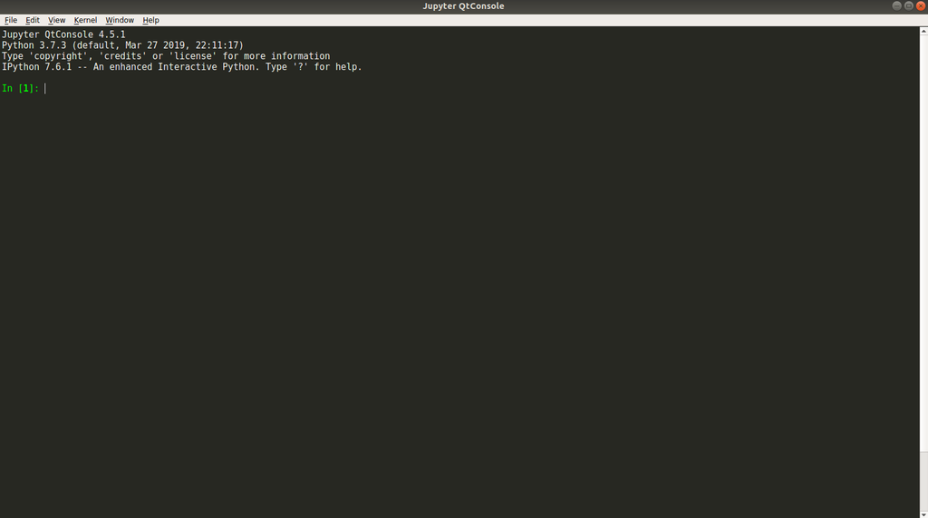

### 1.5.3 Obtenir de l'aide

L'aide est disponible dans les sessions IPython en utilisant la fonction `help(function)`. Certaines fonctions (et modules) ont des fichiers d'aide très longs. Lors de l'utilisation d'IPython, ceux-ci peuvent être parcourus à l'aide de la commande `?function` ou `function?` de sorte que le texte puisse être défilé en utilisant haut et bas et q pour quitter. `?? function` ou `function??` peuvent être utilisées.

### 1.5.4 Exécuter des programmes python

La programmation interactive est utile pour apprendre un langage ou développer rapidement un code simple. Les projets complexes nécessitent l'utilisation de programmes complets. Les programmes peuvent être exécutés soit à l'aide de la commande IPython `%run program.py` ou en lançant directement le programme Python en utilisant l'interpréteur standard à l'aide de `python program.py`. L'avantage d'utiliser l'environnement IPython est que les variables utilisées dans l'environnement peuvent être inspectées une fois l'exécution du programme terminée. Les programmes peuvent être exécutés dans l'interpéteur python standard en utilisant la commande suivante :

```python
exec(compile(open(’filename.py’).read(),’filename.py’,’exec’))
```

Pour tester qu'on peut exécuter avec succès un programme Python, entrons le code dans le bloc ci-dessous dans un fichier sous le nom `firstprogram.py`.

```python
# First Python program
import time
print('Welcome to your first Python program.')
input('Press enter to exit the program.')
print('Bye!')
time.sleep(2)
```

Une fois le fichier sauvegardé, on ouvre la console, allons jusqu'au répertoire dans lequel nous avons sauvegardé le fichier et entrer `python firstprogram.py`. Enfin, exécuter le programme en IPython en lançant d'abord IPython, puis en utilisant `%cd` pour changer l'emplacement du programme, et en exécutant le programme en utilisant `%run firstprogram.py`.

### 1.5.5 %pylab and %matplotlib

Lors de l'écriture de code Python, seul un petit ensemble de fonctions de base et de types de variables sont disponibles dans l'interpréteur. La méthode standard pour accéder à d'autres types de variables ou fonctions est d'utiliser des `import`s, qui permettent explicitement l'accès à des librairies ou fonctions spécifiques. Bien qu'il soit préférable de n'importer que les librairies ou fonctions utiles, il y a beaucoup de fonctions dans plusieurs packages qui sont communément rencontrées. Pylab est une collection de fonctions NumPy, SciPy et Matplotlib courantes qui peuvent être facilement importées à l'aide d'une seule commande `%pylab` dans une session IPython. La plupart des parties du cours supposent que `%pylab` a été appelé pour que les fonctions fournies par `NumPy` puissent être appelées sans les importer explicitement.

### 1.5.6 Tester l'environnement

Pour s'assurer que nous avons correctement installé les composants requis, lancer IPython en utilisant un raccourci ou en exécutant ipython ou jupyter qtconsole dans une fenêtre de terminal. Entrez les commandes suivantes, une à la fois (la signification des commandes sera traitée plus loin dans ce cours).

`>>> %pylab qt5`

`>>> x = randn(100,100)`

`>>> y = mean(x,0)`

`>>> import seaborn`

`>>> plot(y)`

`>>> import scipy as sp`

### 1.5.7 jupyter notebook

jupyter notebook est une méthode simple et utile pour partager du code avec d'autres personnes. Les notebooks permettent une synthèse fluide du texte formaté, de la composition mathématique (en utilisant LATEX via MathJax) et de Python. La principale méthode d'utilisation des notebooks est l'interface Web, qui permet la création, la suppression, l'exportation et l'édition interactive des notebooks.

Pour lancer le serveur jupyter notebook, ouvrir un invite de commande ou un terminal et entrer

`jupyter notebook`

Cette commande démarre le serveur et ouvre le navigateur par défaut qui doit être une version moderne de Chrome (préférable), Chromium ou Firefox. Si le navigateur par défaut est Safari, Internet Explorer ou Edge, l'URL peut être copiée et collée dans Chrome. Cliquez sur nouveau notebook pour en créer un. Les notebooks peuvent être importés.

### 1.5.8 Spyder

Un IDE semblable à RStudio est Spyder

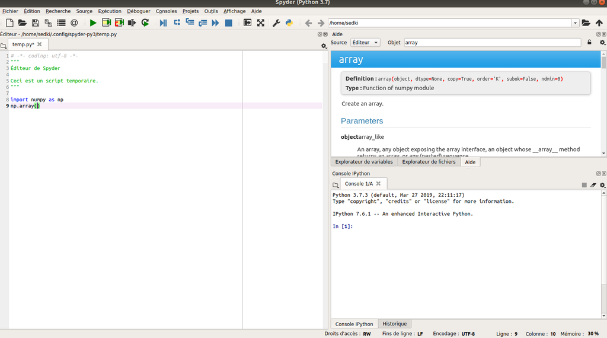

## Annexe : environnements virtuels

La méthode la plus simple pour installer un environnement python scientifique est d'utiliser directement Anaconda. On décrit ici, des options d'installation alternatives utilisant des environnements virtuels, qui permettent à d'autres configurations de co-exister simultanément sur le même système. Le principal avantage d'un environnement virtuel est qu'il permet de geler les versions de librairies afin que le code qui met à jour un module ou l'ensemble d'Anaconda ne le fasse pas dans un environnement virtuel particulier.

### Windows

L'installation sous Windows nécessite le téléchargement du programme d'installation et son exécution. Ces instructions utilisent ANACONDA pour indiquer le répertoire d'installation d'Anaconda (par exemple, la valeur par défaut est C:\Anaconda). Une fois l'installation terminée, ouvrez une invite de commande (cmd.exe) et exécuter le code

`cd ANACONDA`

`conda update conda`

`conda update anaconda`

`conda create -n courspython qtconsole notebook matplotlib numpy pandas scipy spyder statsmodels`

`conda install -n courspython cython lxml nose numba numexpr pytables sphinx xlrd xlwt html5lib seaborn`

qui s'assurera d'abord qu'Anaconda est à jour, puis créera un environnement virtuel appelé *courspython*. L'utilisation d'un environnement virtuel est une pratique exemplaire et importante car les mises à jour de composants peuvent entraîner des erreurs dans des programmes qui fonctionnaient. La longue liste des modules de la commande `conda create` inclut les modules (ou librairies) de base. `conda install` contient les paquets (packages ou librairies) restants et sert d'exemple pour ajouter des paquets à un environnement virtuel existant. après sa création. Il est également possible d'installer tous les paquets Anaconda disponibles en utilisant la commande

`conda create -n courspython anaconda`

L'environnement *courspython* doit être activé avant son utilisation. Pour l'activer, exécuter

`ANACONDA\Scripts\activate.bat courspython`

de command prompt. La présence de `(courspython)` qui précède command prompt est une indication que l'environnement virtuel est actif. Activer l'environnement `courspython`, puis exécuter

`cd c:\`

`ipython`

qui ouvrira une session IPython en utilisant l'environnement virtuel nouvellement créé.

Des environnements virtuels peuvent également être créés à l'aide de versions spécifiques de librairies. Par exemple, pour créer un environnement virtuel sous python2 en utilisant Python 2.7 et NumPy 1.10,

`conda create -n python2 python=2.7 numpy=1.10 scipy pandas`